# Question 2: Geospatial Data (30 marks)

Shared with you are two files:

1. “sg_air.Rdata” contains various air quality indictors from 11 locations in Singapore.
2. “sg_regions.geojson” contains the region boundaries of Singapore.

```r
library(sf); library(tmap); library(gstat)
tmap_options(show.warnings=F, show.messages=F)
```

Answer the following questions:

1. Give spatial awareness to the “sg_air.Rdata” dataset. Prepare your dataset for analysis and give a basic plot of your dataset (5 marks)

```r
#############
# Load data #
#############

sg_regions = st_read("sg_regions.geojson")
table(st_is_valid(sg_regions))
```

```
##
## TRUE
##    5
```

```r
st_crs(sg_regions)$proj4string # not projected
```

```
## [1] "+proj=longlat +datum=WGS84 +no_defs"
```

```r
CRS = "+proj=tmerc +lat_0=1.366666666666667 +lon_0=103.8333333333333 +k=1 +x_0=28001.642 +y_0=38744.572 +datum=WGS84 +units=m +no_defs"
sg_regions = st_transform(sg_regions, crs=CRS)
st_is_longlat(sg_regions)
```

```
## [1] FALSE
```

```r
(sg = st_union(sg_regions))
```

```
## Geometry set for 1 feature
## Geometry type: MULTIPOLYGON
## Dimension:     XY
## Bounding box:  xmin: 2667.537 ymin: 15748.72 xmax: 56396.44 ymax: 50256.33
## Projected CRS: +proj=tmerc +lat_0=1.366666666666667 +lon_0=103.8333333333333 +k=1 +x_0=28001.642 +y_0=38744.572 +datum=WGS84 +units=m +no_defs
```

```
## MULTIPOLYGON (((17763.38 15889.1, 17758.61 1586...
```

```r
load("sg_air.Rdata"); sg_air
```

```
##             Station Country      lon      lat US_AQI PM2.5 PM10   O3 NO2 SO2
## 1   Singapore River      SG 103.8493 1.288538     91  31.4   na   na  na  na
## 2  200 Braddel Road      SG 103.8583 1.344355     90  30.6   na   na  na  na
## 3    Gladiola Drive      SG 103.8294 1.354744     88  29.7   na   na  na  na
## 4          NUS_SDE4      SG 103.7705 1.296910     82  26.9   na   na  na  na
## 5    Robertson Quay      SG 103.8392 1.289724     74    23   na   na  na  na
## 6       Medway Park      SG 103.7761 1.306240     64  18.1   na   na  na  na
## 7             South      SG 103.8325 1.286717     55    14   27  0.6  86   5
## 8              East      SG 103.9615 1.348567     50    12   25 18.4       5
## 9             North      SG 103.7942 1.415789     29     7   22 44.6  36   4
## 10             West      SG 103.6971 1.323551     29     7   22 15.5  24   7
## 11          Central      SG 103.8319 1.305031     22    na   24  1.9  56   3
## 12           Larkin      MY 103.7400 1.497424     81  26.3   na   na  na  na
## 13     Pasir Gudang      MY 103.9053 1.456554     54  13.4   na   na  na  na
## 14        Pengerang      MY 104.1111 1.364700     43  10.3   na   na  na  na
##    CO
## 1  na
## 2  na
## 3  na
## 4  na
## 5  na
## 6  na
## 7  na
## 8  na
## 9   0
## 10 na
## 11 na
## 12 na
## 13 na
## 14 na
```

```r
sg_air = st_as_sf(sg_air, coords=c("lon", "lat"), crs=4326)
class(sg_air); st_crs(sg_air)$proj4string
```

```
## [1] "sf"         "data.frame"
```

```
## [1] "+proj=longlat +datum=WGS84 +no_defs"
```

```r
sg_air = st_transform(sg_air, crs=CRS)
st_is_longlat((sg_air))
```

```
## [1] FALSE
```

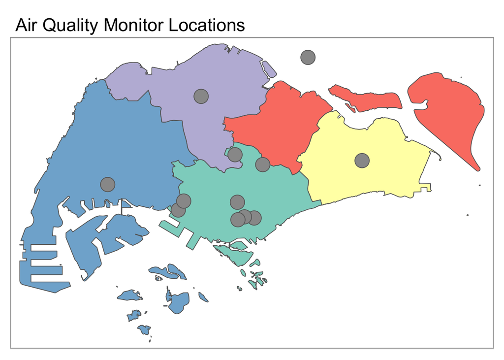

```r
tm_shape(sg_regions) + tm_polygons(col = "Region") +
  tm_shape(sg_air) + tm_bubbles() +
  tm_layout(main.title = "Air Quality Monitor Locations", legend.show = F)
```

```r
#######################
# VORONOI TESSELATION #
#######################

sg_air_sp = as(sg_air,"Spatial")
voro_sp = dismo::voronoi(sg_air_sp)
(voro_sf = voro_sp %>% st_as_sf() %>% st_intersection(sg))
```

```
## Simple feature collection with 14 features and 9 fields
## Geometry type: GEOMETRY
## Dimension:     XY
## Bounding box:  xmin: 8232.854 ymin: 27574.23 xmax: 56396.44 ymax: 50256.33
## Projected CRS: +proj=tmerc +lat_0=1.36666666666667 +lon_0=103.833333333333 +k=1 +x_0=28001.642 +y_0=38744.572 +datum=WGS84 +units=m +no_defs
## First 10 features:
##             Station Country US_AQI PM2.5 PM10   O3 NO2 SO2 CO
## 1   Singapore River      SG     91  31.4   na   na  na  na na
## 2  200 Braddel Road      SG     90  30.6   na   na  na  na na
## 3    Gladiola Drive      SG     88  29.7   na   na  na  na na
## 4          NUS_SDE4      SG     82  26.9   na   na  na  na na
## 5    Robertson Quay      SG     74    23   na   na  na  na na
## 6       Medway Park      SG     64  18.1   na   na  na  na na
## 7             South      SG     55    14   27  0.6  86   5 na
## 8              East      SG     50    12   25 18.4       5 na
## 9             North      SG     29     7   22 44.6  36   4  0
## 10             West      SG     29     7   22 15.5  24   7 na
##                          geometry
## 1  POLYGON ((37075.17 31443.75...
## 2  POLYGON ((36696.71 32155.63...
## 3  POLYGON ((28405.32 34712.54...
## 4  MULTIPOLYGON (((24009.22 27...
## 5  POLYGON ((29012.66 28417.32...
## 6  POLYGON ((24713.46 30818.38...
## 7  POLYGON ((29012.66 28417.32...
## 8  MULTIPOLYGON (((50342.34 39...
## 9  POLYGON ((21358.82 38332.53...
## 10 MULTIPOLYGON (((17434.5 339...
```

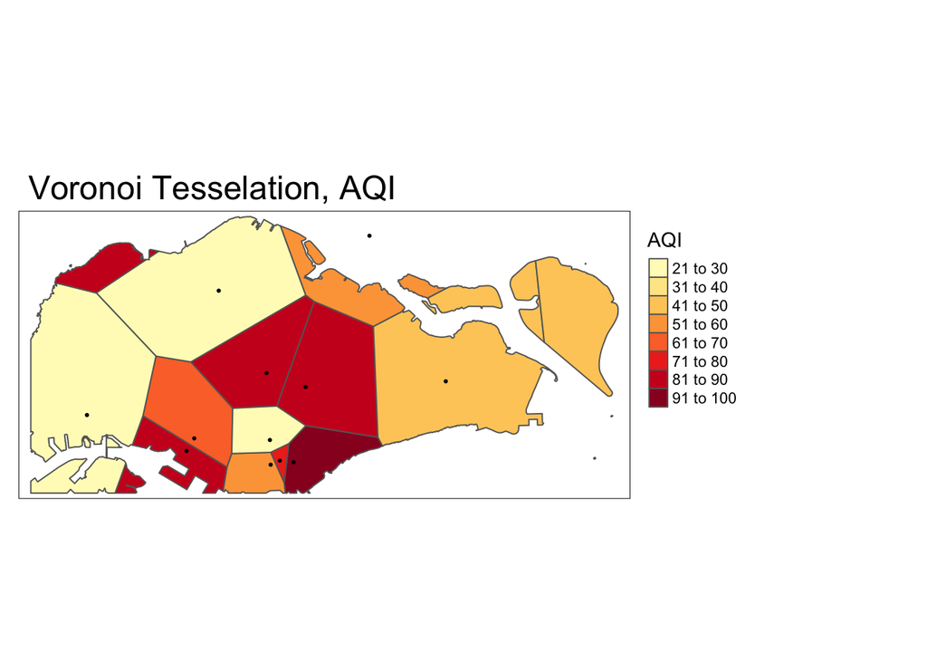

```r
(voro_plot = tm_shape(voro_sf) + tm_polygons(col="US_AQI", palette="YlOrRd", title="AQI") +
    tm_shape(sg_air) + tm_dots() +
    tm_layout(main.title='Voronoi Tesselation, AQI', legend.outside=T))
```

3. Reconstruct the surface using the inverse distance weighting method where the “idp=1” and “idp=3”. Your output must show the head of the interpolated estimates and plots of the estimates. Which idp is more appropriate? (5 marks)

```r
#####################
# IDW INTERPOLATION #
#####################

(sg_grid = sg %>% st_sample(size=10000, type="regular") %>% st_set_crs(CRS))
```

```
## Geometry set for 10004 features
## Geometry type: POINT
## Dimension:     XY
## Bounding box:  xmin: 2735.751 ymin: 16721.37 xmax: 56242.54 ymax: 50058.06
## Projected CRS: +proj=tmerc +lat_0=1.366666666666667 +lon_0=103.8333333333333 +k=1 +x_0=28001.642 +y_0=38744.572 +datum=WGS84 +units=m +no_defs
## First 5 geometries:
```

```
## POINT (17022.9 16721.37)
```

```
## POINT (17303.04 16721.37)
```

```
## POINT (16742.76 17001.51)
```

```
## POINT (17022.9 17001.51)
```

```
## POINT (17303.04 17001.51)
```

```r
# idp = 1
(idw1 = idw(US_AQI~1, locations=sg_air, newdata=sg_grid, idp = 1))
```

```
## [inverse distance weighted interpolation]
```

```
## Simple feature collection with 10004 features and 2 fields
## Geometry type: POINT
## Dimension:     XY
## Bounding box:  xmin: 2735.751 ymin: 16721.37 xmax: 56242.54 ymax: 50058.06
## Projected CRS: +proj=tmerc +lat_0=1.366666666666667 +lon_0=103.8333333333333 +k=1 +x_0=28001.642 +y_0=38744.572 +datum=WGS84 +units=m +no_defs
## First 10 features:
##    var1.pred var1.var                  geometry
## 1   61.92753       NA  POINT (17022.9 16721.37)
## 2   61.96028       NA POINT (17303.04 16721.37)
## 3   61.89963       NA POINT (16742.76 17001.51)
## 4   61.93366       NA  POINT (17022.9 17001.51)
## 5   61.96748       NA POINT (17303.04 17001.51)
## 6   61.90460       NA POINT (16742.76 17281.65)
## 7   61.93976       NA  POINT (17022.9 17281.65)
## 8   61.97469       NA POINT (17303.04 17281.65)
## 9   62.00935       NA POINT (17583.18 17281.65)
## 10  61.87294       NA POINT (16462.62 17561.79)
```

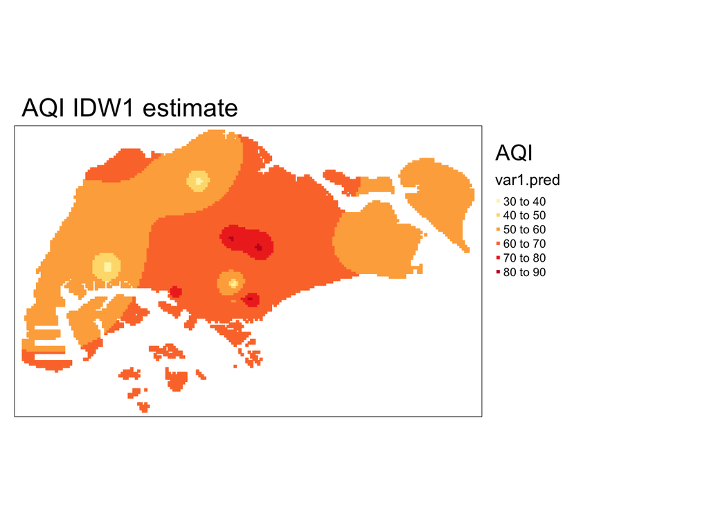

```r
(idw1_plot = tm_shape(idw1) + tm_symbols(col="var1.pred", palette="YlOrRd", size=0.05, shape=15) +
    tm_layout(legend.outside=T, title="AQI", main.title="AQI IDW1 estimate"))
```

```r
# idp = 3
(idw3 = idw(US_AQI~1, locations=sg_air, newdata=sg_grid, idp = 3))
```

```
## [inverse distance weighted interpolation]
```

```
## Simple feature collection with 10004 features and 2 fields
## Geometry type: POINT
## Dimension:     XY
## Bounding box:  xmin: 2735.751 ymin: 16721.37 xmax: 56242.54 ymax: 50058.06
## Projected CRS: +proj=tmerc +lat_0=1.366666666666667 +lon_0=103.8333333333333 +k=1 +x_0=28001.642 +y_0=38744.572 +datum=WGS84 +units=m +no_defs
## First 10 features:
##    var1.pred var1.var                  geometry
## 1   63.29854       NA  POINT (17022.9 16721.37)
## 2   63.40517       NA POINT (17303.04 16721.37)
## 3   63.20080       NA POINT (16742.76 17001.51)
## 4   63.31420       NA  POINT (17022.9 17001.51)
## 5   63.42417       NA POINT (17303.04 17001.51)
## 6   63.21357       NA POINT (16742.76 17281.65)
## 7   63.33075       NA  POINT (17022.9 17281.65)
## 8   63.44425       NA POINT (17303.04 17281.65)
## 9   63.55393       NA POINT (17583.18 17281.65)
## 10  63.10217       NA POINT (16462.62 17561.79)
```

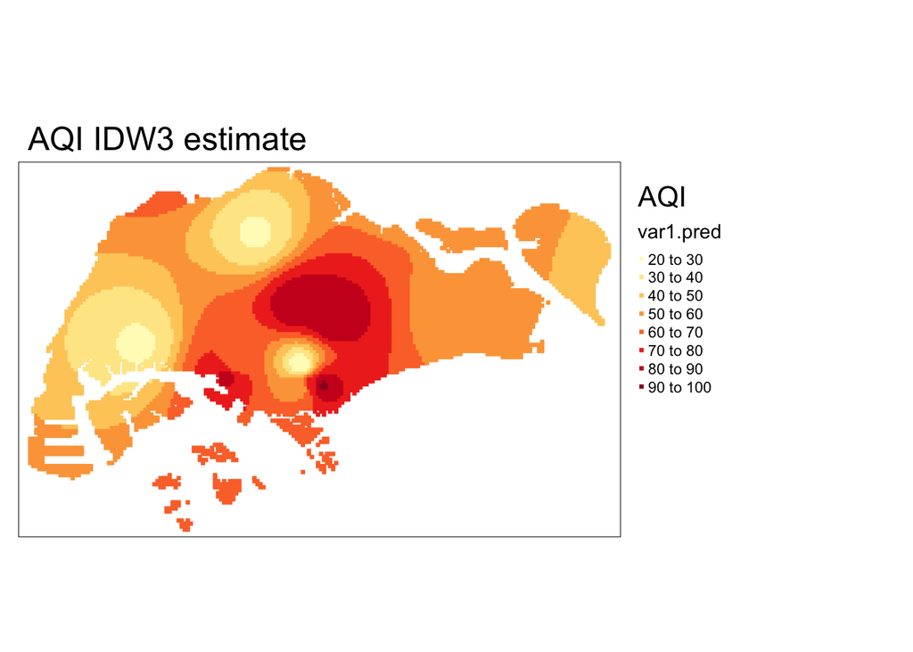

```r
(idw3_plot = tm_shape(idw3) + tm_symbols(col="var1.pred", palette="YlOrRd", size=0.05, shape=15) +
    tm_layout(legend.outside=T, title="AQI", main.title="AQI IDW3 estimate"))
```

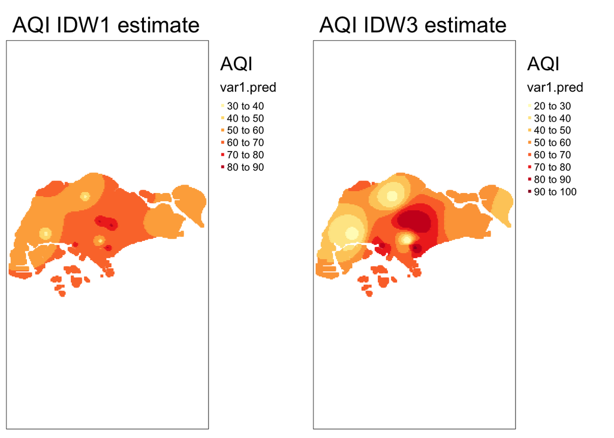

```r
tmap_arrange(idw1_plot, idw3_plot, nrow=1)
```

```r
# idp=3 is better than idp=1 when comparing against the Voronoi tessellation
```

4. Use the autofitVariogram() function to find the most suitable parametric model fit for the empirical semi-variogram. Use this fitted model to predict the US-AQI using ordinary kriging method. Your final answer should include (5 marks):
1. Plot of the fitted variogram.

```r
############################
# SEMI-VARIOGRAM & KRIGING #
############################

# Autofit Variogram
sg_air_sp = as(sg_air, "Spatial")
(autovgm = automap::autofitVariogram(US_AQI~1, sg_air_sp))
```

```
## $exp_var
##   np      dist    gamma dir.hor dir.ver   id
## 1 12  3185.383 898.8750       0       0 var1
## 2 16  7624.306 507.8125       0       0 var1
## 3  6 10552.125 733.4167       0       0 var1
## 4  8 13368.082 553.5625       0       0 var1
## 5 14 15504.886 696.3571       0       0 var1
##
## $var_model
##   model    psill    range
## 1   Nug 649.7132    0.000
## 2   Sph 108.3658 3928.596
##
## $sserr
## [1] 0.04466128
##
## attr(,"class")
## [1] "autofitVariogram" "list"
```

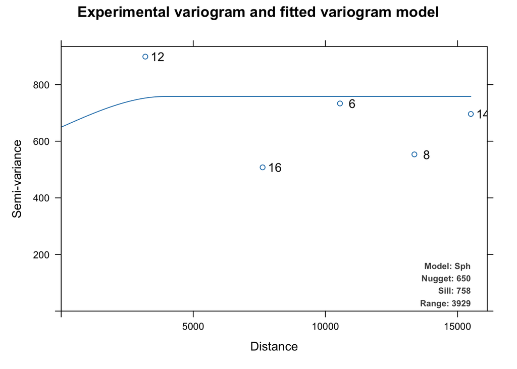

```r
# Spherical model selected
plot(autovgm)
```

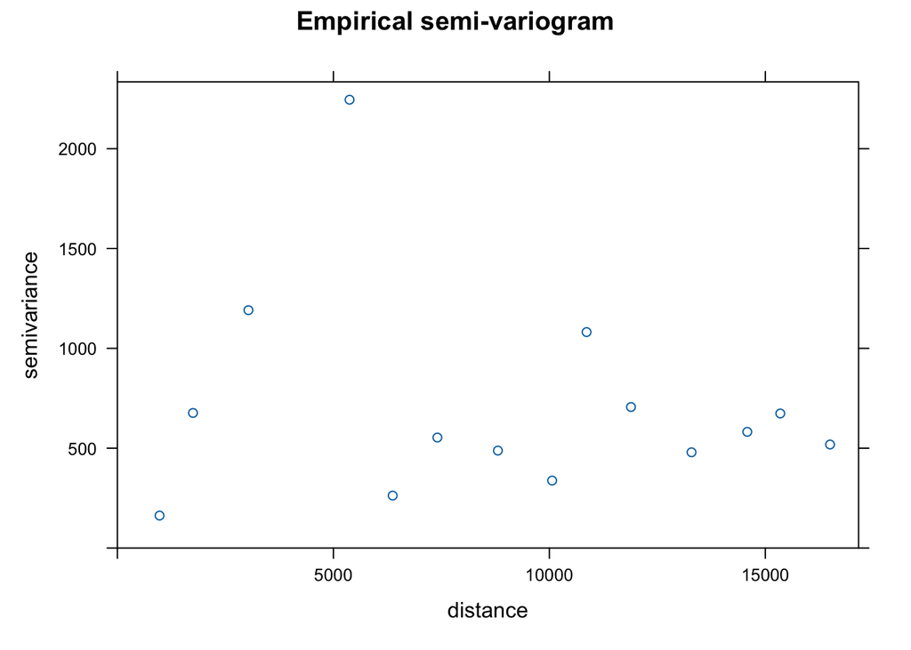

```r
# Empirical variogram
svgm = variogram(US_AQI~1, sg_air)
plot(svgm, main="Empirical semi-variogram")
```

```r
(fvgm.s = fit.variogram(svgm, vgm(psill=500, model="Sph", range=5600, nugget=100), warn.if.neg=T))
```

```
##   model    psill    range
## 1   Nug   0.0000    0.000
## 2   Sph 838.8532 3707.111
```

2. Summary of the predictions.

```r
ok1 = krige(US_AQI~1, locations=sg_air, newdata=sg_grid, model=fvgm.s)
```

```
## [using ordinary kriging]
```

```r
summary(ok1) # no negative estimates, no problem!
```

```
##    var1.pred        var1.var               geometry
##  Min.   :24.47   Min.   : 30.06   POINT        :10004
##  1st Qu.:59.17   1st Qu.:900.11   epsg:NA      :    0
##  Median :59.17   Median :912.58   +proj=tmer...:    0
##  Mean   :59.13   Mean   :865.42
##  3rd Qu.:59.17   3rd Qu.:912.58
##  Max.   :89.41   Max.   :912.58
```

```r
ok1_plot = tm_shape(ok1) + tm_symbols(col="var1.pred", palette="YlOrRd", shape=15, size=0.05) + tm_layout(legend.outside=T, main.title="AQI OK1 estimate")
```

5. Compare the variogram fits using the models: spherical, wave, Matern and pentaspherical. (5 marks)

```r
# Since we used the spherical model in (d), we focus on alternative fits:
(fvgm.w = fit.variogram(svgm, vgm(psill=500, model="Wav", range=5600, nugget=100), warn.if.neg=T))
```

```
##   model    psill    range
## 1   Nug 271.7425    0.000
## 2   Wav 611.2244 5599.999
```

```r
(fvgm.m = fit.variogram(svgm, vgm(psill=500, model="Mat", range=5600, nugget=100), warn.if.neg=T))
```

```
##   model    psill    range kappa
## 1   Nug   0.0000    0.000   0.0
## 2   Mat 856.8006 1900.577   0.5
```

```r
(fvgm.p = fit.variogram(svgm, vgm(psill=500, model="Pen", range=5600, nugget=100), warn.if.neg=T))
```

```
##   model    psill    range
## 1   Nug   0.0000    0.000
## 2   Pen 843.3308 4604.627
```

```r
plot1 = plot(svgm, model=fvgm.s, main="Fitted semi-variogram, spherical model")
plot2 = plot(svgm, model=fvgm.w, main="Fitted semi-variogram, wave model")
plot3 = plot(svgm, model=fvgm.m, main="Fitted semi-variogram, Matern model")
plot4 = plot(svgm, model=fvgm.p, main="Fitted semi-variogram, pentaspherical model")
```

1. Select the model fit that includes a “nugget effect”.

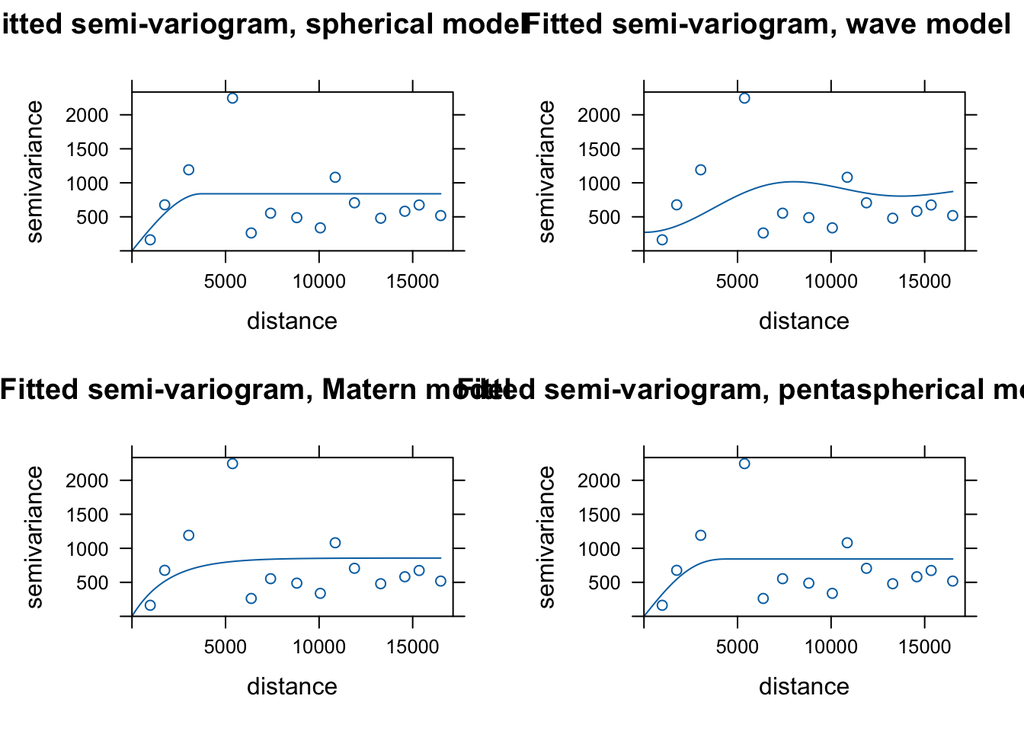

```r
gridExtra::grid.arrange(plot1, plot2, plot3, plot4, nrow = 2)
```

```r
# select "wave" model since all other models set nugget to be 0 which is highly unlikely in this case
```

2. Re-do the answers to part (d) using the new parametric fit.

```r
# Since we plotted a fitted variogram using the wave model in (e), we have already resolved (d) 1. We now focus on (d) 2. and 3. using the same wave model.

# Prediction using the wave model
ok2 = krige(US_AQI~1, locations=sg_air, newdata=sg_grid, model=fvgm.w)
```

```
## [using ordinary kriging]
```

```r
summary(ok2) # no negative estimates, no problem!
```

```
##    var1.pred        var1.var              geometry
##  Min.   :35.22   Min.   :340.6   POINT        :10004
##  1st Qu.:57.10   1st Qu.:692.6   epsg:NA      :    0
##  Median :63.59   Median :894.7   +proj=tmer...:    0
##  Mean   :63.22   Mean   :808.2
##  3rd Qu.:69.99   3rd Qu.:934.3
##  Max.   :92.06   Max.   :992.3
```